# Analyse du bilan d’un Groupe Pétrolier de 1969 à 1984

Date : 07-01-2021

## 1. Présentations

Les données étudiées sont issus des bilans annuels d'un groupe pétrolier sur la période 1969 à 1984. Les postes de bilans suivant chaque année sont décrit ci-dessous:

- *NET* : Situation nette ; représente l’ensemble des capitaux propres de l’entreprise
- *INT* : Intérêts ; représente l’ensemble des frais financiers supportés par l’entreprise.
- *SUB* : Subventions ; représente le montant total des subventions accordées par l’État.
- *LMT* : Dettes à long et moyen terme.
- *DCT* : Dettes à court terme.
- *IMM* : Immobilisations ; représente l’ensemble des terrains et du matériel de l’entreprise.
- *EXP* : Valeurs d’exploitation.
- *VRD* : Valeurs réalisables et disponibles ; ensemble des créances à court terme de l’entreprise.

Les données sont de nature quantitatives et ont été ventilées en pourcentage par année, la somme des éléments d’une même ligne vaut 100, de manière à éviter les effets dus à l’inflation. Et elles se présentent sous la forme suivante:

```
##        NET  INT  SUB   LMT   DCT   IMM   EXP   VRD
## 1969 17.93 3.96 0.88  7.38 19.86 25.45  5.34 19.21
## 1970 16.21 3.93 0.94  9.82 19.11 26.58  5.01 18.40
## 1971 19.01 3.56 1.91  9.43 17.87 25.94  5.40 16.88
## 1972 18.05 3.33 1.73  9.72 18.83 26.05  5.08 17.21
## 1973 16.56 3.10 2.14  9.39 20.36 23.95  6.19 18.31
## 1974 13.09 2.64 2.44  8.10 25.05 19.48 11.61 17.59
## 1975 13.43 2.42 2.45 10.83 22.07 22.13 11.17 15.49
## 1976  9.83 2.46 1.79 11.81 24.10 22.39 11.31 16.30
## 1977  9.46 2.33 2.30 11.46 24.45 23.07 11.16 15.77
## 1978 10.93 2.95 2.25 10.72 23.16 24.17  9.64 16.20
## 1979 13.02 3.74 2.21  7.99 23.04 19.53 12.60 17.87
## 1980 13.43 3.60 2.29  7.09 23.59 17.61 16.67 15.72
## 1981 13.37 3.35 2.58  6.76 23.94 18.04 15.42 16.54
## 1982 11.75 2.74 3.11  7.37 25.04 18.11 14.71 17.18
## 1983 12.59 3.05 3.85  7.12 23.40 19.17 11.86 18.97
## 1984 13.00 3.00 4.00  7.00 24.00 20.00 12.00 17.00
```

Dans la suite de notre analyse, nous tenterons d'apporter des éléments de réponse aux questions suivantes:

- *Quelle a été l’évolution de la structure de bilan sur 15 ans ?*
- *Peut-on mettre en évidence plusieurs périodes ? Si oui, comment se caractérisent-elles ?*

## 2. Statistiques Descriptives

```r
summary(BD)
```

```
##       NET             INT             SUB             LMT
##  Min.   : 9.46   Min.   :2.330   Min.   :0.880   Min.   : 6.760
##  1st Qu.:12.38   1st Qu.:2.715   1st Qu.:1.880   1st Qu.: 7.308
##  Median :13.23   Median :3.075   Median :2.270   Median : 8.745
##  Mean   :13.85   Mean   :3.135   Mean   :2.304   Mean   : 8.874
##  3rd Qu.:16.30   3rd Qu.:3.570   3rd Qu.:2.482   3rd Qu.:10.045
##  Max.   :19.01   Max.   :3.960   Max.   :4.000   Max.   :11.810
##       DCT             IMM             EXP              VRD
##  Min.   :17.87   Min.   :17.61   Min.   : 5.010   Min.   :15.49
##  1st Qu.:20.23   1st Qu.:19.40   1st Qu.: 5.992   1st Qu.:16.27
##  Median :23.28   Median :22.26   Median :11.240   Median :17.09
##  Mean   :22.37   Mean   :21.98   Mean   :10.323   Mean   :17.16
##  3rd Qu.:24.02   3rd Qu.:24.49   3rd Qu.:12.150   3rd Qu.:17.98
##  Max.   :25.05   Max.   :26.58   Max.   :16.670   Max.   :19.21
```

Nous notons d’abord qu’il n’y a pas de symétrie des variables. Seulement nous avons les variables INT, LMT, NET, SUB et VRD qui ont des moyennes supérieures à leurs médianes respectives. Ce qui permet de dire qu’il y a plus de 50% des valeurs de chacune de ces variables respectives qui sont inférieures à leurs moyennes respectives.

#### 2.1 Histogrammes de l'évolution du bilan :

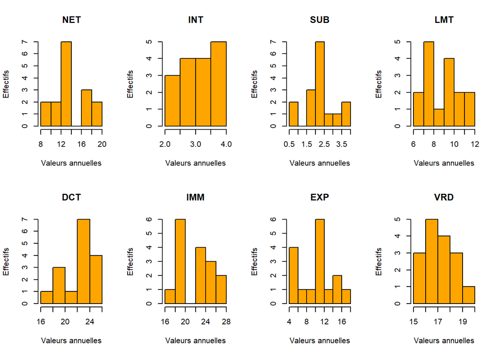

```r
par(mfrow=c(2,4))
hist(BD$NET, col = c("orange"),main = paste("NET"),ylab = "Effectifs",xlab = "Valeurs annuelles")
hist(BD$INT, col = c("orange"),main = paste("INT"),ylab = "Effectifs",xlab = "Valeurs annuelles")
hist(BD$SUB, col = c("orange"),main = paste("SUB"),ylab = "Effectifs",xlab = "Valeurs annuelles")
hist(BD$LMT, col = c("orange"),main = paste("LMT"),ylab = "Effectifs",xlab = "Valeurs annuelles")

#par(mfrow=c(2,2))
hist(BD$DCT, col = c("orange"),main = paste("DCT"),ylab = "Effectifs",xlab = "Valeurs annuelles")
hist(BD$IMM, col = c("orange"),main = paste("IMM"),ylab = "Effectifs",xlab = "Valeurs annuelles")
hist(BD$EXP, col = c("orange"),main = paste("EXP"),ylab = "Effectifs",xlab = "Valeurs annuelles")
hist(BD$VRD, col = c("orange"),main = paste("VRD"),ylab = "Effectifs",xlab = "Valeurs annuelles")
```

Et quant aux variables DCT, EXP et SUB, elles ont connu une augmentation au fil du temps.

#### **2.2 Matrice de Corrélation :**

```r
MatCor<-round(cor(BD),4)
MatCor
```

```
##         NET     INT     SUB     LMT     DCT     IMM     EXP     VRD
## NET  1.0000  0.6861 -0.4614 -0.2041 -0.8908  0.5536 -0.7045  0.4784
## INT  0.6861  1.0000 -0.4494 -0.4600 -0.6007  0.2455 -0.3398  0.5296
## SUB -0.4614 -0.4494  1.0000 -0.4093  0.6127 -0.6932  0.6079 -0.1421
## LMT -0.2041 -0.4600 -0.4093  1.0000 -0.1884  0.5976 -0.3904 -0.4195
## DCT -0.8908 -0.6007  0.6127 -0.1884  1.0000 -0.8168  0.8644 -0.3535
## IMM  0.5536  0.2455 -0.6932  0.5976 -0.8168  1.0000 -0.9446  0.2021
## EXP -0.7045 -0.3398  0.6079 -0.3904  0.8644 -0.9446  1.0000 -0.4614
## VRD  0.4784  0.5296 -0.1421 -0.4195 -0.3535  0.2021 -0.4614  1.0000
```

Une relation linéaire positive existe entre les variables DCT et EXP.

- DCT et EXP, 0.8644

Une relation linéaire négative existe entre les variables DCT et NET, DCT et IMM, EXP et IMM

- DCT et NET, -0.8908
- DCT et IMM, -0.8168
- EXP et IMM, -0.9446
- NET et EXP, -0.7045

**Valeurs propres:**

```r
eigen(MatCor)$values
```

```
## [1]  4.470445e+00  2.114851e+00  6.806677e-01  5.007378e-01  1.595878e-01
## [6]  6.409009e-02  9.663594e-03 -4.259124e-05
```

**Vecteurs propres:**

```r
eigen(MatCor)$vectors
```

```
##             [,1]         [,2]        [,3]        [,4]        [,5]        [,6]
## [1,] -0.40209004 -0.238460175  0.07653820 -0.47232629  0.50015626  0.07476364
## [2,] -0.29777451 -0.427521894  0.45245048  0.16597696 -0.62821425  0.02304934
## [3,]  0.35101042 -0.189656719 -0.49803838 -0.57951877 -0.47383501  0.05134780
## [4,] -0.09468098  0.661260877 -0.05952474  0.11119916 -0.19002823  0.55270867
## [5,]  0.45114198 -0.001148934 -0.06374103  0.36718171  0.12934364 -0.47407568
## [6,] -0.41047614  0.307828864 -0.15053368 -0.01743851 -0.27035815 -0.52676884
## [7,]  0.43783563 -0.144273590  0.36268908  0.04516224  0.01912264  0.31250238
## [8,] -0.23186495 -0.414187588 -0.61609931  0.51379580  0.06611549  0.29302690
##            [,7]      [,8]
## [1,] -0.3228581 0.4387788
## [2,] -0.3076740 0.0802988
## [3,] -0.1166848 0.1271465
## [4,] -0.3568156 0.2625760
## [5,] -0.5370318 0.3573564
## [6,]  0.3745413 0.4721505
## [7,]  0.4698833 0.5788682
## [8,]  0.1034023 0.1737664
```

## 3. Réalisation de l'ACP centrée réduite

```r
library(FactoMineR)
res.ACP<-PCA(BD, scale.unit = TRUE, ncp=5, graph = FALSE)
summary(res.ACP, nbind=16)
```

```
##
## Call:
## PCA(X = BD, scale.unit = TRUE, ncp = 5, graph = FALSE)
##
##
## Eigenvalues
##                        Dim.1   Dim.2   Dim.3   Dim.4   Dim.5   Dim.6   Dim.7
## Variance               4.470   2.115   0.681   0.501   0.160   0.064   0.010
## % of var.             55.880  26.436   8.508   6.259   1.995   0.802   0.121
## Cumulative % of var.  55.880  82.315  90.823  97.083  99.078  99.879 100.000
##                        Dim.8
## Variance               0.000
## % of var.              0.000
## Cumulative % of var. 100.000
##
## Individuals
##          Dist    Dim.1    ctr   cos2    Dim.2    ctr   cos2    Dim.3    ctr
## 1969 |  4.016 |  3.557 17.685  0.784 |  1.505  6.697  0.141 | -0.043  0.017
## 1970 |  3.705 |  3.575 17.873  0.931 | -0.043  0.005  0.000 | -0.226  0.469
## 1971 |  3.424 |  3.120 13.612  0.830 | -0.218  0.141  0.004 | -0.342  1.074
## 1972 |  3.042 |  2.876 11.560  0.893 | -0.548  0.886  0.032 |  0.032  0.010
## 1973 |  2.128 |  1.849  4.782  0.755 |  0.024  0.002  0.000 |  0.950  8.293
## 1974 |  1.882 | -1.424  2.836  0.573 |  0.322  0.306  0.029 |  0.571  2.998
## 1975 |  2.381 | -0.795  0.883  0.111 | -1.972 11.494  0.686 | -0.208  0.399
## 1976 |  2.915 | -1.161  1.884  0.159 | -2.504 18.530  0.738 | -0.010  0.001
## 1977 |  3.137 | -1.597  3.567  0.259 | -2.658 20.873  0.718 |  0.178  0.290
## 1978 |  1.961 | -0.379  0.201  0.037 | -1.748  9.030  0.795 | -0.061  0.034
## 1979 |  1.807 | -0.362  0.183  0.040 |  1.356  5.435  0.563 | -0.533  2.610
## 1980 |  2.980 | -1.760  4.329  0.349 |  1.203  4.277  0.163 | -2.065 39.167
## 1981 |  2.496 | -1.750  4.282  0.492 |  1.400  5.794  0.315 | -1.074 10.599
## 1982 |  2.697 | -2.518  8.867  0.872 |  0.841  2.091  0.097 |  0.306  0.862
## 1983 |  2.954 | -1.379  2.659  0.218 |  1.886 10.510  0.408 |  1.724 27.282
## 1984 |  2.620 | -1.852  4.797  0.500 |  1.153  3.929  0.194 |  0.801  5.897
##        cos2
## 1969  0.000 |
## 1970  0.004 |
## 1971  0.010 |
## 1972  0.000 |
## 1973  0.199 |
## 1974  0.092 |
## 1975  0.008 |
## 1976  0.000 |
## 1977  0.003 |
## 1978  0.001 |
## 1979  0.087 |
## 1980  0.480 |
## 1981  0.185 |
## 1982  0.013 |
## 1983  0.340 |
## 1984  0.094 |
##
## Variables
##         Dim.1    ctr   cos2    Dim.2    ctr   cos2    Dim.3    ctr   cos2
## NET  |  0.850 16.167  0.723 |  0.347  5.686  0.120 | -0.063  0.584  0.004 |
## INT  |  0.630  8.868  0.396 |  0.622 18.278  0.387 | -0.373 20.470  0.139 |
## SUB  | -0.742 12.321  0.551 |  0.276  3.597  0.076 |  0.411 24.815  0.169 |
## LMT  |  0.200  0.896  0.040 | -0.962 43.726  0.925 |  0.049  0.354  0.002 |
## DCT  | -0.954 20.353  0.910 |  0.002  0.000  0.000 |  0.053  0.406  0.003 |
## IMM  |  0.868 16.849  0.753 | -0.448  9.476  0.200 |  0.124  2.266  0.015 |
## EXP  | -0.926 19.169  0.857 |  0.210  2.082  0.044 | -0.299 13.155  0.090 |
## VRD  |  0.490  5.376  0.240 |  0.602 17.155  0.363 |  0.508 37.949  0.258 |
```

#### **3.1 Choix du nombre d'axes à retenir:**

##### **Critère du Coude :**

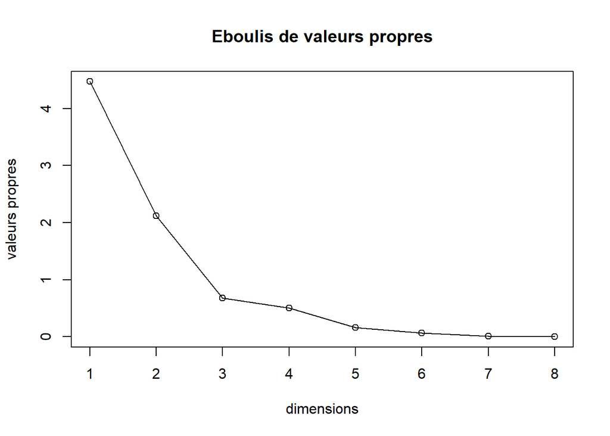

```r
plot(res.ACP$eig[,1],type="o",main = "Eboulis de valeurs propres",
     xlab ="dimensions",ylab = "valeurs propres")
```

Le graphique de l'éboulis des valeurs propres montre un premier coude après la 2nde valeur, cependant après cette même 2nde valeur la décroissance de l'inertie beaucoup devient très faible. Naturellement, on ne s'intéressera donc qu'aux 2 premiers axes.

##### **Critère de Kaiser :**

```r
res.ACP$eig[,1:3]
```

```
##          eigenvalue percentage of variance cumulative percentage of variance
## comp 1 4.470371e+00           5.587964e+01                          55.87964
## comp 2 2.114846e+00           2.643557e+01                          82.31522
## comp 3 6.806590e-01           8.508237e+00                          90.82345
## comp 4 5.007466e-01           6.259332e+00                          97.08279
## comp 5 1.595783e-01           1.994729e+00                          99.07751
## comp 6 6.414833e-02           8.018542e-01                          99.87937
## comp 7 9.649896e-03           1.206237e-01                          99.99999
## comp 8 6.169196e-07           7.711495e-06                         100.00000
```

Le critère de Kaiser nous conduit de même à retenir que 2 axes, expliquant plus de **82%** de l'inertie totale.

**Conclusion :**

- Le premier facteur est prépondérant, il conserve **55.87%** de l’inertie du nuage. Il est peu probable qu’il soit dû au hasard. Il existe une structuration importante des données qui va se manifester sur le premier axe (1/2 au lieu de 1/8).
- Le second axe quand à lui, il conserve une part importante de l’inertie totale, soit **26.43%**.
- En effet, d’un côté, la chute d’inertie est très importante dès le troisième axe, qui ne conserve plus que **8.5%** de l’inertie totale.

Nous décidons dorénavant de ne retenir que les 2 premiers axes (le premier plan factoriel) car il est compréhensible à l’œil et ne déforme pas trop le nuage (il explique 82% de l’inertie du nuage).

#### **3.2 Graphiques :**

##### **3.2.1 Graphiques des individus:**

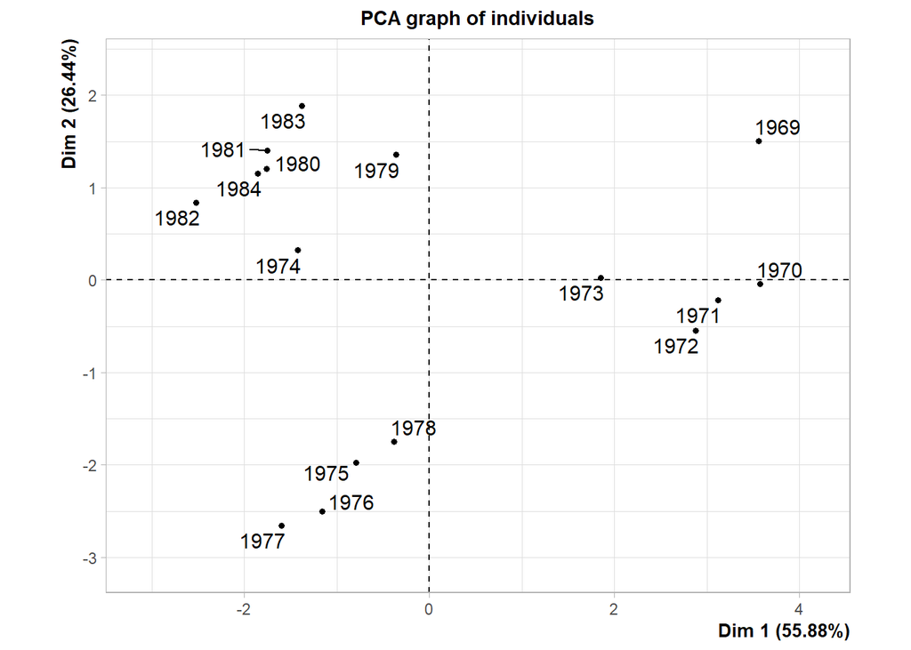

```r
plot.PCA(res.ACP, axes=c(1, 2), choix="ind", label="ind",new.plot=TRUE)
```

##### **3.2.2 Graphique des variables:**

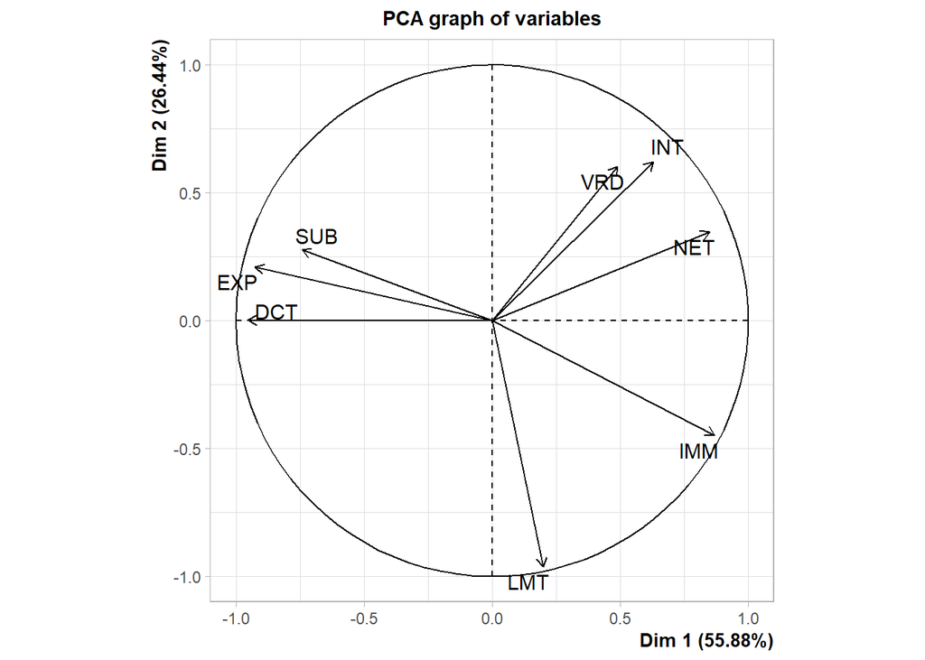

```r
plot.PCA(res.ACP, axes=c(1, 2), choix="var", new.plot=TRUE, col.var="black", label="var")
```

#### **3.3 Interprétations :**

##### **3.3.1 Analyse pour l'Axe 1:**

###### *Individus (Contributions et Qualités de représentations):*

```r
res.ACP$ind$contrib[,1:2] #Contributions
```

```
##           Dim.1        Dim.2
## 1969 17.6852726  6.696932501
## 1970 17.8731585  0.005396725
## 1971 13.6119827  0.140556846
## 1972 11.5603440  0.886130626
## 1973  4.7816644  0.001634611
## 1974  2.8362985  0.306312287
## 1975  0.8831080 11.494306711
## 1976  1.8835332 18.529798990
## 1977  3.5668834 20.872550456
## 1978  0.2010138  9.030262877
## 1979  0.1827104  5.435003799
## 1980  4.3290197  4.277458825
## 1981  4.2817065  5.794419888
## 1982  8.8671686  2.090958345
## 1983  2.6593682 10.509590779
## 1984  4.7967675  3.928685734
```

```r
res.ACP$ind$cos2[,1:2]    #Qualités de représentations des individus sur les axes (Cos2)
```

```
##           Dim.1        Dim.2
## 1969 0.78440555 0.1405205718
## 1970 0.93109538 0.0001330020
## 1971 0.83031221 0.0040560857
## 1972 0.89331553 0.0323941776
## 1973 0.75516781 0.0001221276
## 1974 0.57268607 0.0292593174
## 1975 0.11144325 0.6862111824
## 1976 0.15850676 0.7377008838
## 1977 0.25930891 0.7178589564
## 1978 0.03739019 0.7946343620
## 1979 0.04004247 0.5634983552
## 1980 0.34867902 0.1629885784
## 1981 0.49152375 0.3146825532
## 1982 0.87166477 0.0972400092
## 1983 0.21797482 0.4075198325
## 1984 0.49999758 0.1937321104
```

En comparant les valeurs de la première colonne du tableau des contributions à la racine de la première valeur propre sqrt(lambda)=sqrt(4.470445)=2.114343 .

Nous voyons bien que les années **1969, 1970, 1971 1972** et **1982** contribuent le plus a la formation del'axe. En plus de leur bonne qualité de representation, les 4 premiers sont du même côté de l'axe. Tandis que l'année **1982** se trouve du côté opposé.

De plus, grâce au premier axe, nous identifions une opposition de la structure de bilan l’année **1982** aux quatre années précédant le choc pétrolier de 1973.(Voir PCA graph of individuals)  
Ainsi donc l'axe met la lumière sur les zones qui se dégagent notamment l'avant et l'aprés le choc.

En plus des années contribuant fortement à l’axe, il y'a aussi les individus **1973**, **1974**, **1981** et **1984** qui ont une bonne qualité de représentation.

###### *Variables (Coordonnées et Contributions):*

```r
res.ACP$var$coord[,1:2]     #Coordonnées
```

```
##          Dim.1       Dim.2
## NET  0.8501446  0.34677614
## INT  0.6296300  0.62173016
## SUB -0.7421449  0.27580372
## LMT  0.2001719 -0.96162832
## DCT -0.9538576  0.00167783
## IMM  0.8678731 -0.44767280
## EXP -0.9257141  0.20985062
## VRD  0.4902545  0.60232544
```

```r
res.ACP$var$contrib[,1:2]/5 #Trier pour axe 1: contributions
```

```
##         Dim.1        Dim.2
## NET 3.2334932 1.137234e+00
## INT 1.7736060 3.655571e+00
## SUB 2.4641309 7.193687e-01
## LMT 0.1792638 8.745120e+00
## DCT 4.0705532 2.662242e-05
## IMM 3.3697586 1.895277e+00
## EXP 3.8338943 4.164586e-01
## VRD 1.0752999 3.430945e+00
```

Nous identifions les variables **NET**, **SUB**, **DCT**, **IMM**, **EXP** contribuant le plus à la formation de l'axe. Les variables **NET** et **IMM** sont du même côté de l'axe tandis que **SUB**, **DCT** et **EXP** sont du côté opposé.

Contrairement aux autres variables dont la qualite de representation est moyenne, Seules les variables LMT et VRD semblent ne pas être bien representés par l'axe.

##### **3.3.2 Analyse pour l'Axe 2:**

###### *Individus (Contributions et Qualités de représentations):*

```r
res.ACP$ind$contrib[,1:2] #Contributions
```

```
##           Dim.1        Dim.2
## 1969 17.6852726  6.696932501
## 1970 17.8731585  0.005396725
## 1971 13.6119827  0.140556846
## 1972 11.5603440  0.886130626
## 1973  4.7816644  0.001634611
## 1974  2.8362985  0.306312287
## 1975  0.8831080 11.494306711
## 1976  1.8835332 18.529798990
## 1977  3.5668834 20.872550456
## 1978  0.2010138  9.030262877
## 1979  0.1827104  5.435003799
## 1980  4.3290197  4.277458825
## 1981  4.2817065  5.794419888
## 1982  8.8671686  2.090958345
## 1983  2.6593682 10.509590779
## 1984  4.7967675  3.928685734
```

```r
res.ACP$ind$cos2[,1:2]    #Qualités de représentations des individus sur les axes (Cos2)
```

```
##           Dim.1        Dim.2
## 1969 0.78440555 0.1405205718
## 1970 0.93109538 0.0001330020
## 1971 0.83031221 0.0040560857
## 1972 0.89331553 0.0323941776
## 1973 0.75516781 0.0001221276
## 1974 0.57268607 0.0292593174
## 1975 0.11144325 0.6862111824
## 1976 0.15850676 0.7377008838
## 1977 0.25930891 0.7178589564
## 1978 0.03739019 0.7946343620
## 1979 0.04004247 0.5634983552
## 1980 0.34867902 0.1629885784
## 1981 0.49152375 0.3146825532
## 1982 0.87166477 0.0972400092
## 1983 0.21797482 0.4075198325
## 1984 0.49999758 0.1937321104
```

Ainsi le 2ème axe oppose les années de **1975** à **1978** aux années **1983** et **1969**.  
Les années 1975 à 1978 se trouvent entre 2 chocs pétroliers. A noté que les années 83 et 69 sont assez mal représentées sur l’axe.

###### *Variables (Coordonnées et Contributions):*

```r
res.ACP$var$coord[,1:2]     #Coordonnées
```

```
##          Dim.1       Dim.2
## NET  0.8501446  0.34677614
## INT  0.6296300  0.62173016
## SUB -0.7421449  0.27580372
## LMT  0.2001719 -0.96162832
## DCT -0.9538576  0.00167783
## IMM  0.8678731 -0.44767280
## EXP -0.9257141  0.20985062
## VRD  0.4902545  0.60232544
```

```r
res.ACP$var$contrib[,1:2]/5 #Contributions
```

```
##         Dim.1        Dim.2
## NET 3.2334932 1.137234e+00
## INT 1.7736060 3.655571e+00
## SUB 2.4641309 7.193687e-01
## LMT 0.1792638 8.745120e+00
## DCT 4.0705532 2.662242e-05
## IMM 3.3697586 1.895277e+00
## EXP 3.8338943 4.164586e-01
## VRD 1.0752999 3.430945e+00
```

Nous identifions ainsi les variables **INT**, **VRD** et **LMT** contribuant le plus à la formation de l'axe. Les 2 premières variables **INT** et **VRD** sont du même côté de l'axe tandis que **LMT** est du côté opposé.

Le reste des variables ne sont pas bien representés par l'axe, ils seront donc assez mal expliqué par le l'axe.

###### *En Résumé:*

L’axe 2 sépare les années entre les deux chocs, **1975** à **1978**, caractérisées par un poids important du poste **LMT** et un poids faible des postes **VRD** et **INT**.

##### **3.3.3 Synthèse Générale:**

###### **3.3.3.a) Qualité de représentation des individus sur le plan(1,2):**

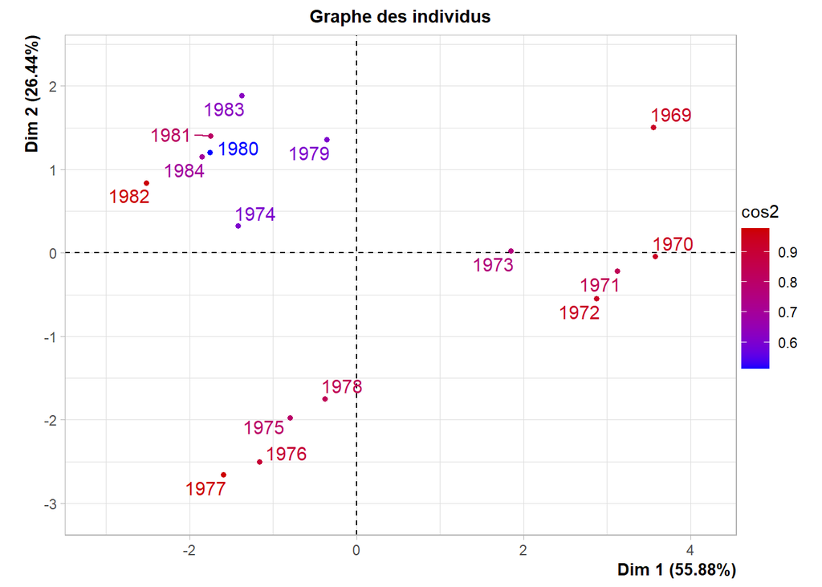

```r
plot.PCA(res.ACP,habillage='cos2',title="Graphe des individus")
```

Les individus ne sont pas tous très bien représentés. En effet, les individus coloriés en rouge sont ceux qui ont une très forte représentation, ensuite en Violet ceux moyennement représentés et enfin en bleu ceux qui ont une qualité de représentation faible.

###### **3.3.3.b) Qualité de représentation des variables sur le plan(1,2):**

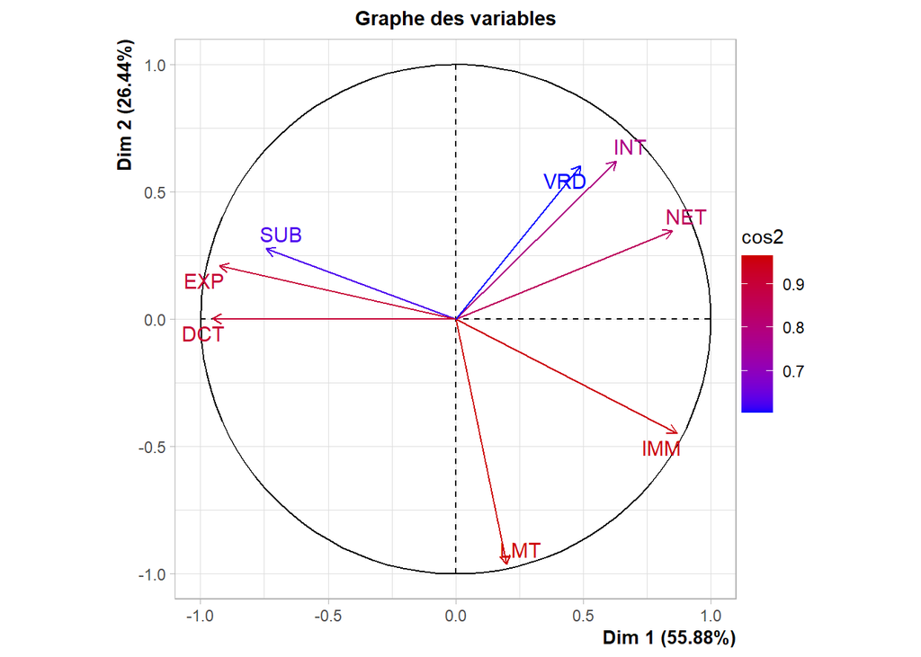

```r
plot.PCA(res.ACP,choix='var',habillage = 'cos2',
         title="Graphe des variables")
```

Les variables non plus ne sont pas tous très bien représentés. De même que les individus, nous avons en rouge sont ceux qui sont fortement représentés, ensuite ceux moyennement représentés en Violet et enfin les plus faibles en bleu.

###### *En Résumé:*

En observant bien le graphe des individus, nous distinguons trois groupes occupant trois zones. Ce qui fait qu'il y'a naturellement trois périodes qui se dégagent: